# Rapport QAQC & Analyses Descriptives - Projet PUDC

15 juillet 2026

## 1. Introduction et Contexte

Ce rapport présente les résultats de la validation de la qualité des données (QAQC) ainsi que les analyses descriptives de l’enquête du Programme d’Urgence de Développement Communautaire (PUDC) réalisée au Sénégal.

Les bases analysées contiennent : - **`df_hh` (Ménages)** : 1686 ménages observés. - **`df_ind` (Individus)** : 14609 individus observés.

## Synthèse Exécutive

Le présent rapport documente le traitement, la validation (QAQC) et les analyses descriptives de l’enquête PUDC (Programme d’Urgence de Développement Communautaire, Sénégal rural). Les principaux enseignements sont les suivants :

- **Ménages et individus enquêtés** : 1686 ménages et 14609 individus.
- **Accès à l’eau potable améliorée (standard JMP)** : 47,3 %.
- **Index de richesse (ACP, poolé MICE)** : moyenne centrée 0,00, écart-type 1,45.
- **Ménages ayant subi au moins un choc** : 47,1 %.
- **Malnutrition aiguë (déclaration d’œdèmes, 6-59 mois)** : 1,75 %.
- **Ménages orphelins** (sans chef déclaré dans le roster) : 91 (5,4 %).

Le rapport détaille ensuite le diagnostic des données manquantes, l’imputation MICE, les profils démographiques et de logement, puis les cartographies régionales.

## 2. Section A : Statistiques Descriptives Détaillées

### 2.1 Découpage Géographique et Cartes Régionales

Le Sénégal est divisé en plusieurs régions. En couplant nos données avec les limites administratives (shapefile GADM), nous pouvons visualiser spatialement les disparités régionales.

#### Carte 1 : Taux d’accès à l’eau potable améliorée (Standard JMP) par région

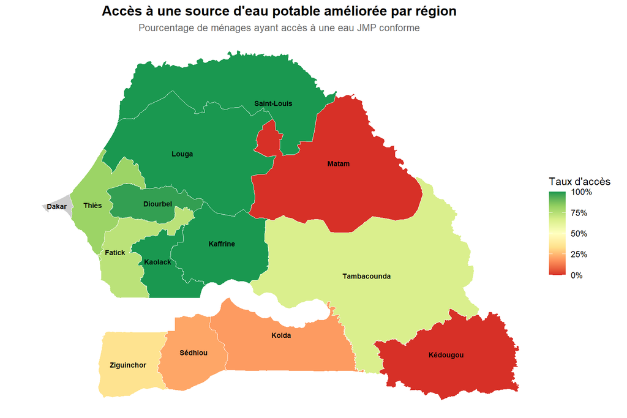

#### Carte 2 : Niveau de richesse moyen (Score ACP) par région

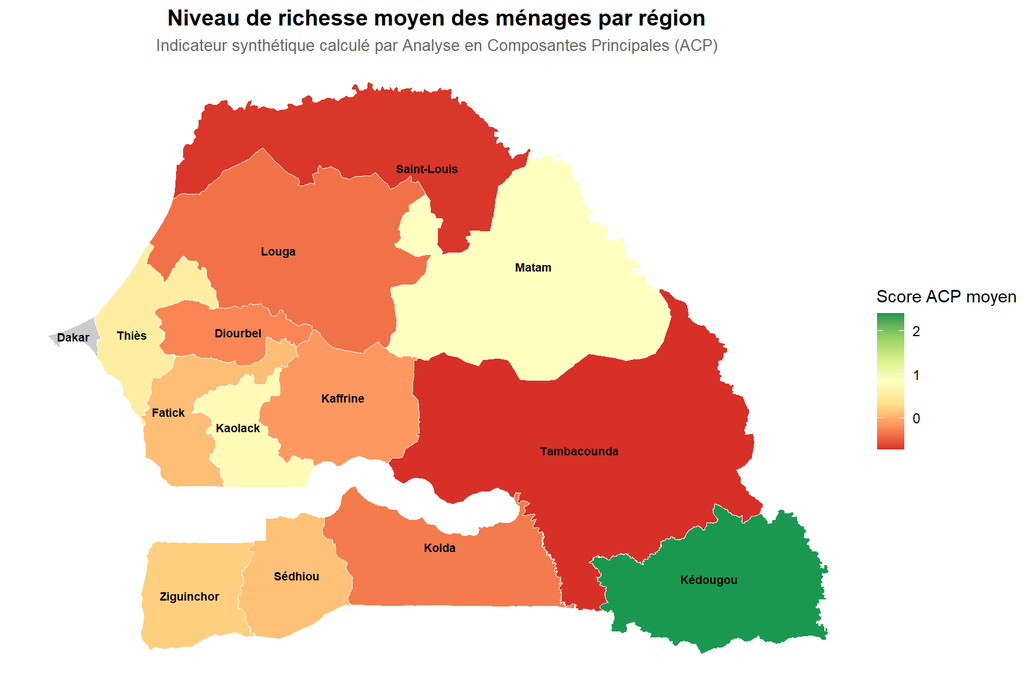

Le tableau ci-dessous synthétise les données régionales cartographiées :

| region | milieu_label | Ménages | Eau améliorée (%) | Chocs subis (%) | Score richesse (ACP) moyen |
| --- | --- | --- | --- | --- | --- |
| DIOURBEL | Rural | 90 | 97.8 | 35.6 | -0.24 |
| FATICK | Non renseigné | 1 | 0 | 0 | 0.67 |
| FATICK | Rural | 18 | 77.8 | 50 | 0.08 |
| KAFFRINE | Non renseigné | 5 | 100 | 100 | 0.09 |
| KAFFRINE | Rural | 66 | 100 | 83.3 | -0.14 |
| KAOLACK | Rural | 47 | 100 | 38.3 | 0.63 |
| KAOLACK | Urbain | 6 | 100 | 16.7 | 1.75 |
| KEDOUGOU | Non renseigné | 1 | 0 | 0 | 3.75 |
| KEDOUGOU | Rural | 1 | 0 | 0 | 1.07 |
| KOLDA | Non renseigné | 32 | 0 | 0 | 0.78 |

[output cut: 16 more lines]

## 2b. Diagnostic et mécanisme des données manquantes

Le pipeline diagnostique la complétude et le mécanisme des données manquantes avant toute imputation (non-réponse ; MCAR/MAR/MNAR). Les actifs manquants sont imputés par MICE (méthode `logreg`) ; le Périmètre Brachial (MUAC) étant absent à 100 % (le round ne l’a pas collecté), il est traité comme MNAR structurel et n’est pas imputé.

[output not shown]

### Visualisation de la distribution et du mécanisme des données manquantes

#### Comparaison Avant / Après Imputation (MICE)

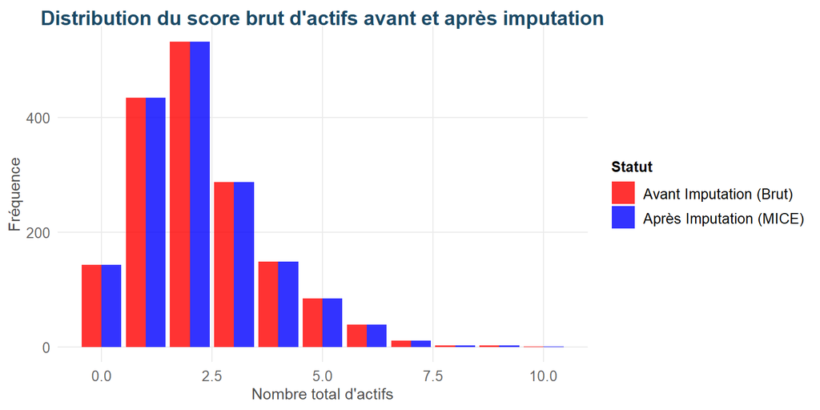

#### Visualisation bivariée du mécanisme de non-réponse

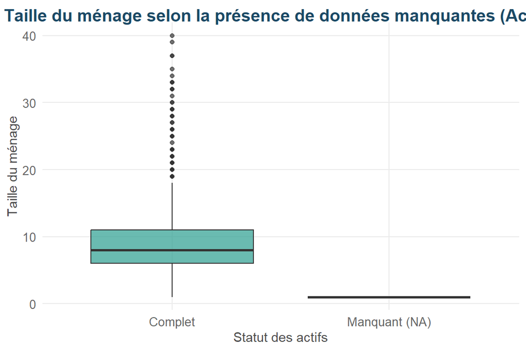

## 3. Structure Démographique de la Population

| Indicateur | Valeur |
| --- | --- |
| Proportion de femmes | 51.08% |
| Âge moyen des membres | 23.06 ans |
| Proportion d'enfants (&lt; 5 ans) | 11.27% |

### Répartition par âge et sexe

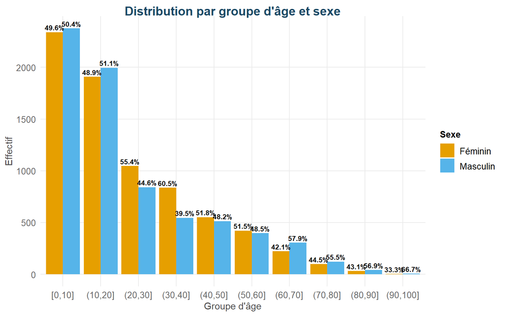

## 4. Caractéristiques du Logement et Accès aux Services

### Accès à l’Eau Potable (Standard JMP)

L’accès à une source d’eau potable améliorée a été recalculé conformément aux standards JMP de l’OMS/UNICEF.

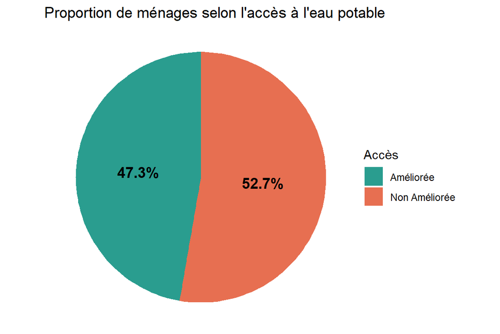

#### Accès à l’Assainissement Amélioré

L’assainissement est mesuré par le type de toilettes utilisées par le ménage.

| assainissement_ameliore | Effectif | Proportion |
| --- | --- | --- |
| Amélioré | 999 | 59.3 |
| Non Amélioré | 687 | 40.7 |

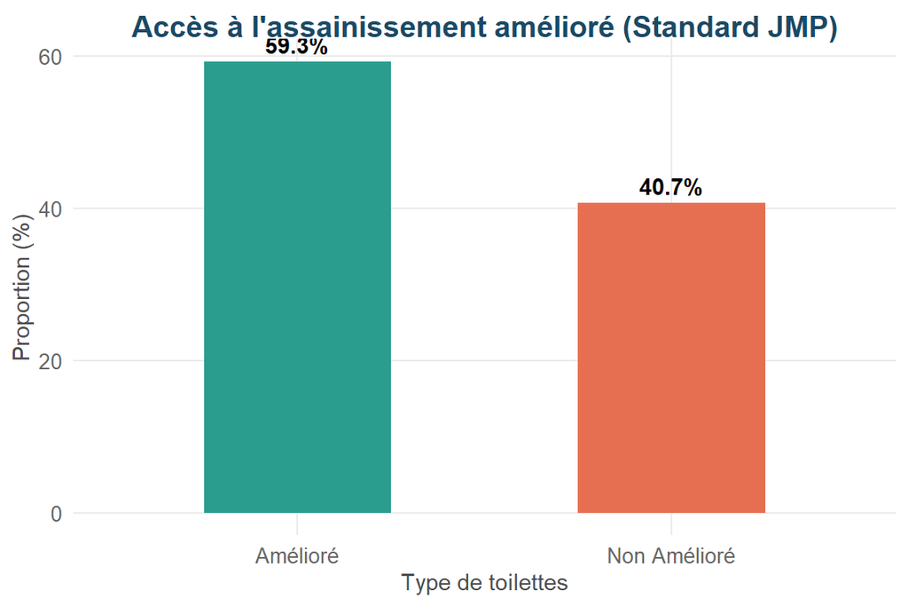

### Éducation et Caractéristiques du Chef de Ménage

#### Scolarisation des individus

| Tranche | Taux scolarisation (%) | Total |
| --- | --- | --- |
| Moyen (12-15 ans) | 69.9 | 1805 |
| Primaire (6-11 ans) | 52.3 | 3255 |

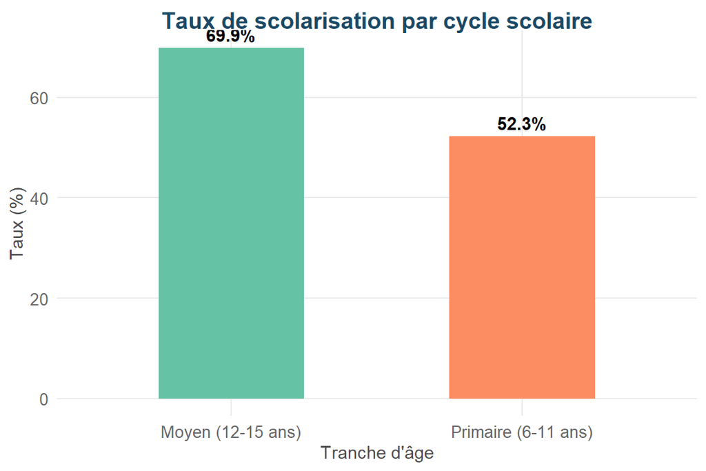

#### Profil du Chef de Ménage

| Indicateur | Valeur |
| --- | --- |
| Âge moyen du Chef de Ménage | 54.3 |
| Proportion de femmes Chefs de Ménage (%) | 17 |
| Taux de scolarisation du Chef de Ménage (%) | 25.5 |

### Caractéristiques du Logement et Emploi

#### Matériaux de construction

| Indicateur | Proportion |
| --- | --- |
| Toit (matériaux améliorés) (%) | 88.4 |
| Murs (matériaux améliorés) (%) | 71.1 |

#### Emploi et Occupation

| occupation | Effectif | Proportion |
| --- | --- | --- |
| 0 | 7683 | 60.2 |
| 1 | 92 | 0.7 |
| 2 | 9 | 0.1 |
| 3 | 54 | 0.4 |
| 4 | 125 | 1 |
| 5 | 99 | 0.8 |
| 6 | 147 | 1.2 |
| 7 | 33 | 0.3 |
| 8 | 2083 | 16.3 |
| 9 | 468 | 3.7 |

[output cut: 3 more lines]

### Actifs possédés et Sources de Revenus

#### Possession des actifs (Détail)

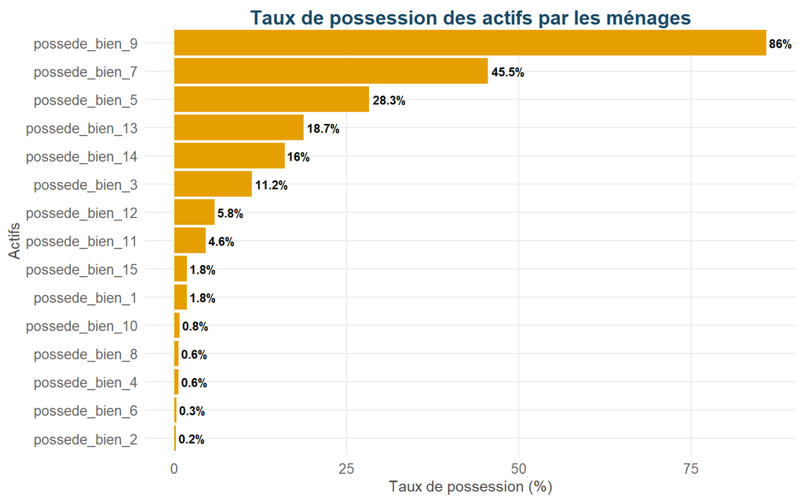

### Index de Richesse (Analyse en Composantes Principales - ACP)

L’indice de richesse a été construit en utilisant une ACP sur la base de la possession de plusieurs actifs.

| Indicateur | Valeur |
| --- | --- |
| Score moyen d'actifs (non pondéré) | 2.37 |
| Index Richesse ACP (Moyenne) | 0 |
| Index Richesse ACP (Min) | -0.99 |
| Index Richesse ACP (Max) | 10.75 |
| Index Richesse ACP (Écart-Type) | 1.45 |
| Nombre moyen de pièces | 4.78 |
| Valeurs aberrantes détectées (Nb pièces) | 61 |

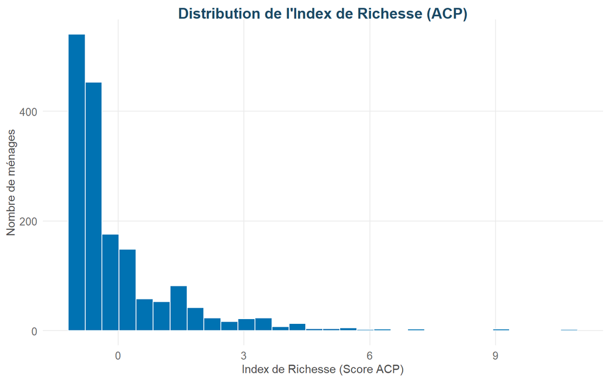

#### Relation bivariée : Taille du ménage vs Score ACP

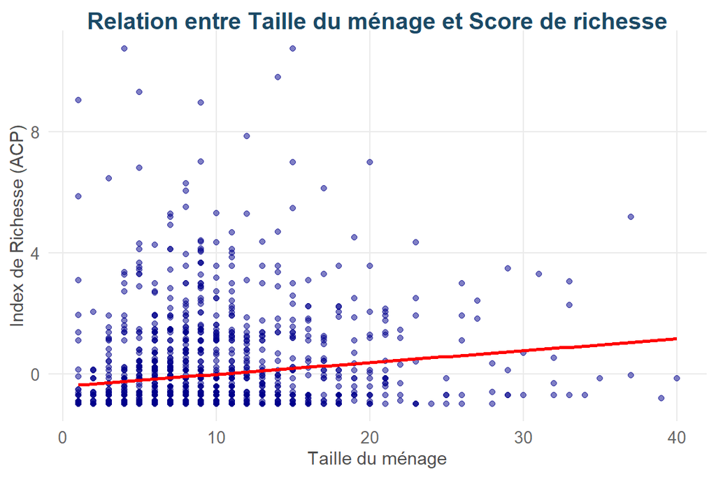

### Quintiles de richesse (méthode DHS)

Les quintiles sont calculés à l’intérieur de chaque milieu (Rural/Urbain) afin de ne pas confondre richesse et milieu.

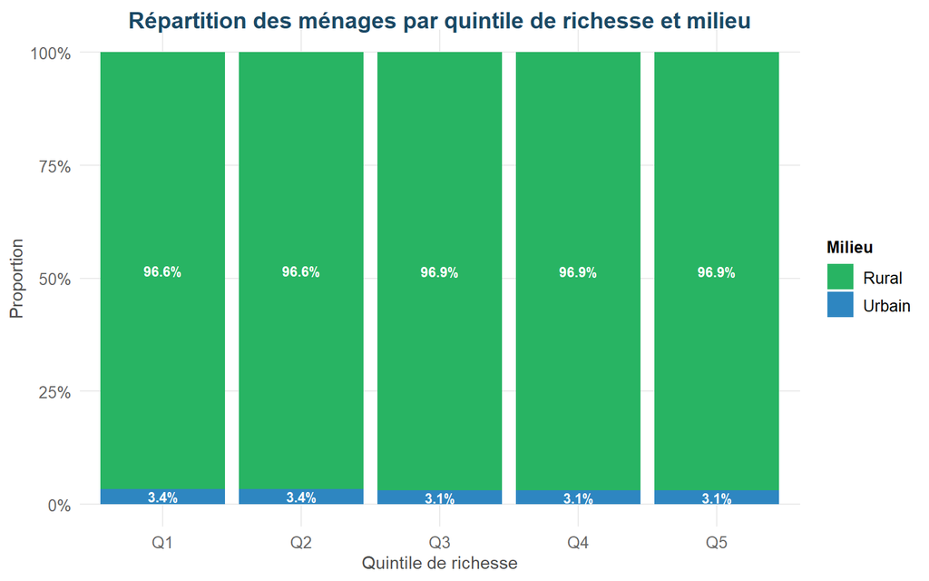

### Index de richesse par région

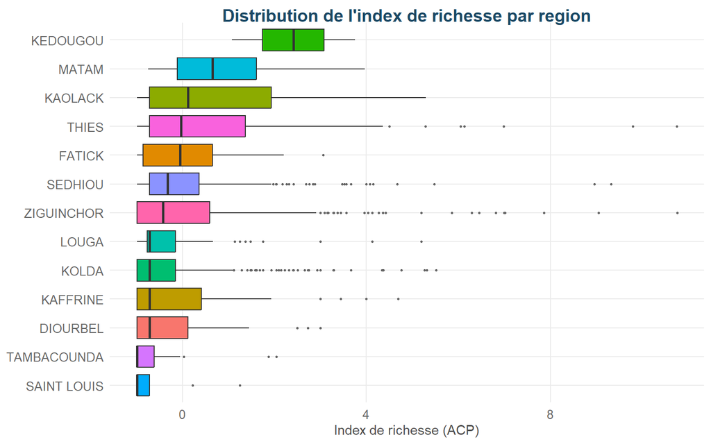

## 5. Chocs, Vulnérabilité et Malnutrition

### Chocs Subis

| Indicateur | Valeur |
| --- | --- |
| Ménages ayant subi au moins un choc | 47.09% |
| Nombre moyen de chocs par ménage | 0.88 |

### Malnutrition Infantile (Enfants de 6 à 59 mois)

L’indicateur de malnutrition a été calculé sur la tranche d’âge cible (6-59 mois) ; comme le Périmètre Brachial (MUAC) est absent à 100 % de la collecte, il repose **uniquement sur la déclaration d’œdèmes**.

| Indicateur | Valeur |
| --- | --- |
| Enfants (6-59 mois) éligibles | 1721 |
| Mesures MUAC valides | 0 |
| Taux de malnutrition (parmi valides) | 1.75% |

```
## **Note :** Aucune mesure MUAC valide n'a été trouvée pour permettre la visualisation de la malnutrition.
```

## Note sur les pondérations d’échantillonnage

Le jeu de données traité ne contient aucune variable de poids d’échantillonnage. Les statistiques et graphiques de ce rapport sont donc des estimations non pondérées. Pour une enquête de type PUDC/EHCVM, les estimations (accès à l’eau, malnutrition, index de richesse) devraient être calculées via un plan d’échantillonnage.

**Exemple d’implémentation (si la variable de poids `hhweight` existait) :**

```r
library(survey)
# Définition du plan de sondage (Grappe = ZD, Strate = Milieu/Région, Poids = hhweight)
pudc_design <- svydesign(id = ~zd_id, strata = ~region+milieu, weights = ~hhweight, data = df_hh)

# Calcul d'une moyenne pondérée pour l'accès à l'eau améliorée
svymean(~eau_amelioree, design = pudc_design, na.rm = TRUE)
```

Recommandation : extraire le poids de l’export Stata via `var_mapping.csv` et répéter les estimations pondérées (voir template EHCVM de référence).